# Week 2: Starting with R

UZH n UU: tested by Jonas

13 February, 2025

# 1 Exercises for the R-Beginner - The fancy calculator

## 1.1 GGPLOT

```r
library(tidyverse)
```

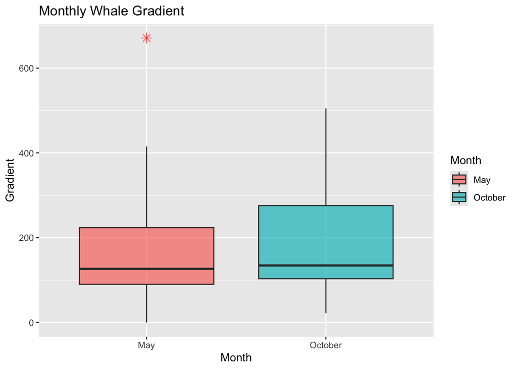

```r
library(dplyr)
whaledata <- readxl::read_excel("whaledata.xls")
whaledata |>
  ggplot(aes(x = month, y = gradient, fill = month)) +
  geom_boxplot(alpha = 0.7, outlier.color = "red", outlier.shape = 8, outlier.size = 3) +
  labs(
    title = "Monthly Whale Gradient",
    x = "Month",
    y = "Gradient",
    fill = "Month"
  )
```

# 2 Session Information

**R version 4.4.1 (2024-06-14)**

**Platform:** aarch64-apple-darwin20

**locale:** en_US.UTF-8||en_US.UTF-8||en_US.UTF-8||C||en_US.UTF-8||en_US.UTF-8

**attached base packages:** *stats*, *graphics*, *grDevices*, *utils*, *datasets*, *methods* and *base*

**other attached packages:** *lubridate(v.1.9.3)*, *forcats(v.1.0.0)*, *stringr(v.1.5.1)*, *dplyr(v.1.1.4)*, *purrr(v.1.0.2)*, *tidyr(v.1.3.1)*, *tibble(v.3.2.1)*, *ggplot2(v.3.5.1)*, *tidyverse(v.2.0.0)* and *readr(v.2.1.5)*

**loaded via a namespace (and not attached):** *sass(v.0.4.9)*, *utf8(v.1.2.4)*, *generics(v.0.1.3)*, *stringi(v.1.8.4)*, *hms(v.1.1.3)*, *digest(v.0.6.37)*, *magrittr(v.2.0.3)*, *evaluate(v.1.0.0)*, *grid(v.4.4.1)*, *timechange(v.0.3.0)*, *bookdown(v.0.42)*, *fastmap(v.1.2.0)*, *cellranger(v.1.1.0)*, *jsonlite(v.1.8.9)*, *fansi(v.1.0.6)*, *pander(v.0.6.5)*, *scales(v.1.3.0)*, *jquerylib(v.0.1.4)*, *cli(v.3.6.3)*, *rlang(v.1.1.4)*, *munsell(v.0.5.1)*, *withr(v.3.0.1)*, *cachem(v.1.1.0)*, *yaml(v.2.3.10)*, *tools(v.4.4.1)*, *tzdb(v.0.4.0)*, *colorspace(v.2.1-1)*, *vctrs(v.0.6.5)*, *R6(v.2.5.1)*, *lifecycle(v.1.0.4)*, *pkgconfig(v.2.0.3)*, *pillar(v.1.9.0)*, *bslib(v.0.8.0)*, *gtable(v.0.3.5)*, *Rcpp(v.1.0.13)*, *glue(v.1.7.0)*, *xfun(v.0.50)*, *tidyselect(v.1.2.1)*, *rstudioapi(v.0.16.0)*, *knitr(v.1.49)*, *farver(v.2.1.2)*, *htmltools(v.0.5.8.1)*, *rmarkdown(v.2.28)*, *labeling(v.0.4.3)*, *compiler(v.4.4.1)* and *readxl(v.1.4.3)*